# ENVIRON 309 Lecture, March 2023

Melissa Mattwig

2023-03-27

## Open Source Geospatial Analyses in R

We are using this R Markdown document to show how R can be used for quick analyses and mapping of geospatial data. We will start by looking at census data in Cuyahoga county, OH (Cleveland).

### First, **what is R?**

R is a language and environment for statistical computing and graphics. Many functionalities in R are through *packages*. An R package is an extension of R containing data sets and specific functions to solve specific questions. Packages are free to download and use.

```r
# For plotting
library(ggplot2)
# For downloading Census data
library(tidycensus)
library(tidyr)
# For creating tmap
library(tmap)
# For reading and processing spatial data related to tmap
library(tmaptools)
# For data wrangling
library(dplyr)
# For reading, writing and working with spatial objects
library(sf)
library(rgeos)
library(rgdal)
library(maptools)
# also loads sp()
library(RColorBrewer) # creates nice color schemes
library(classInt)     # finds class intervals for continuous variables
library(cartography)
library(SpatialPosition)
library(mapsf)
library(maptiles)
library(osmdata)
library(ggpubr)
library(ggmap)
library(ggspatial)
```

## Data setup

Sometimes census data can be computationally expensive due to it’s size, especially since you get ALL the variables when you download the shapefiles from the internet. In R, we can use an [Application Programming Interface (API)](https://en.wikipedia.org/wiki/API) to access the features and data of the census website. In this way, we can specify the only the variables we want to avoid unnecessarily large data sets. In this first example, we will be using an API key to get the median household income for Ohio in 2021 based on the [American Community Survey](https://www.census.gov/programs-surveys/acs/about.html)

```r
## Set working directory, akin to making a folder connection in ArcGIS Pro
setwd("/Users/Matt/Desktop/ENVIRON 309/gsi")
ohio <- get_acs(state = "OH", geography = "tract", variables = "B19013_001", geometry = TRUE, cb = FALSE)
head(ohio)
```

[output not shown]

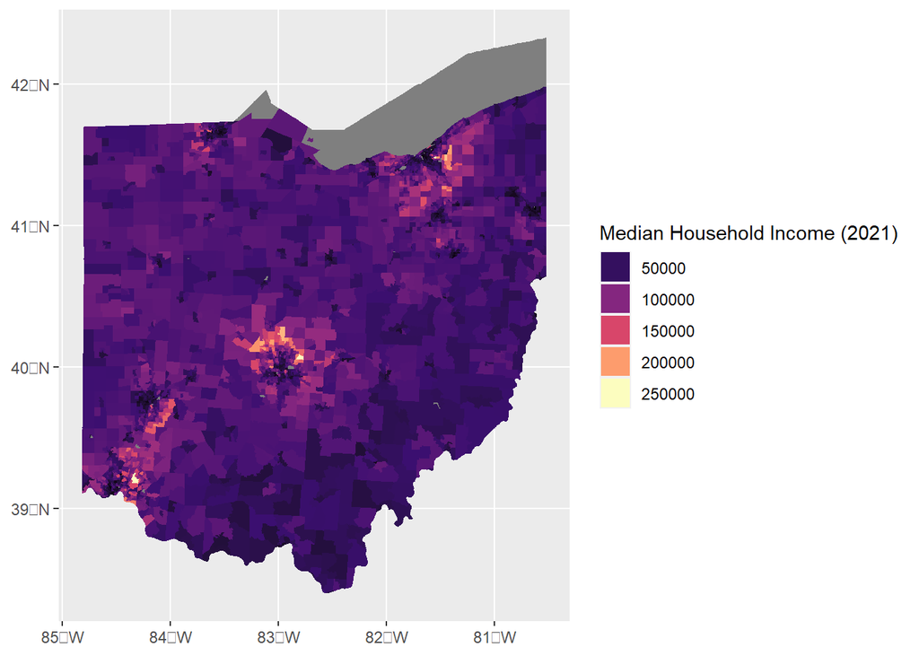

```r
ohio %>%
  ggplot(aes(fill = estimate)) +
  guides(fill=guide_legend(title="Median Household Income (2021)")) +
  geom_sf(color = NA) +
  coord_sf(crs = 4326) +
  scale_fill_viridis_c(option = "magma")
```

Now let’s look at some demographic data in Cuyahoga county, OH (city of Cleveland) using the Census data from 2010

```r
## Here we specify which Census variables we want to include
demovars <- c(White = "P005003",
              Black = "P005004",
              Asian = "P005006",
              Hispanic = "P004003",
              HouseUnits = "H001001",
              Rent = "H004004" )

## Now let's use the API call again to get ACS data for Cuyahoga county
cuyahoga <- get_decennial(geography = "tract", variables = demovars,
                       state = "OH", county = "Cuyahoga County", geometry = TRUE,
                       summary_var = "P001001")

## Here we are reprojecting the data to NAD83 / Ohio North
cuyahoga <- st_transform(cuyahoga, crs = 32122)

## Here we are changing the setup of the table to have a more intuitive spread of the demographic variables (as columns rather than separate rows)
cuyahoga <- cuyahoga %>%
  spread(variable, value) %>%
  rename("Pop2010" = "summary_value")
```

What other kinds of maps can we make with this data?

Let’s start with a [Choropleth Map](https://en.wikipedia.org/wiki/Choropleth_map)

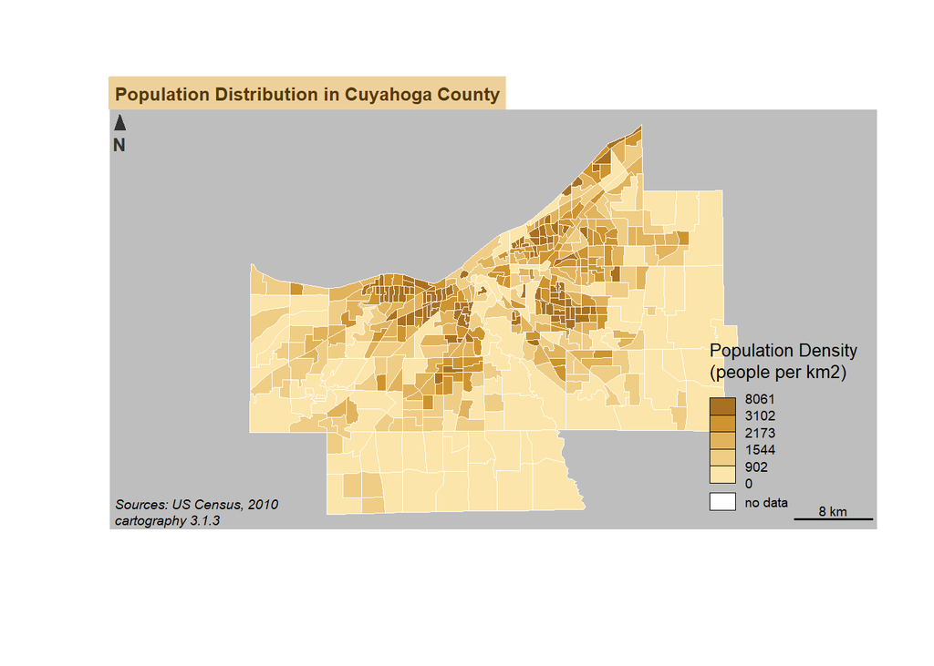

```r
cuyahoga$PopDens <- 1e6 * cuyahoga$Pop2010 / st_area(cuyahoga)
# plot municipalities (only the backgroung color is plotted)
plot(st_geometry(cuyahoga), col = NA, border = NA, bg = "gray")
# plot population density
choroLayer(
  x = cuyahoga,
  var = "PopDens",
  method = "quantile",
  nclass=5,
  col = carto.pal(pal1 = "sand.pal", n1 = 5),
  border = "white",
  lwd = 0.5,
  legend.pos = "bottomright",
  legend.title.txt = "Population Density\n(people per km2)",
  add = TRUE
)
# layout
layoutLayer(title = "Population Distribution in Cuyahoga County",
            sources = "Sources: US Census, 2010",
            author = paste0("cartography ", packageVersion("cartography")),
            frame = FALSE, north = FALSE, tabtitle = TRUE, theme= "sand.pal")
# north arrow
north(pos = "topleft")
```

Now let’s look at a Grid map, which is nice because it can remove the arbitrariness of administrative divisions in the Census

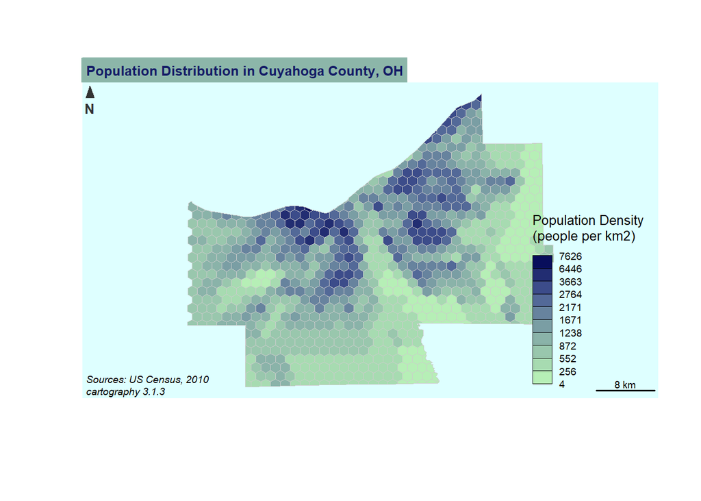

```r
## First we build the regular grid
mygrid <- getGridLayer(
  x = na.omit(cuyahoga),
  cellsize = median(as.numeric(st_area(cuyahoga))),
  var = "Pop2010",
  type = "hexagonal"
)
## Now we compute population density in people per km2
mygrid$PopDens <- 1e6 * mygrid$Pop2010 / mygrid$gridarea
plot(st_geometry(cuyahoga), col = NA, border = NA, bg = "#deffff")
# Plot the population density for the grid
choroLayer(x = mygrid, var = "PopDens", method = "fisher-jenks", nclass=10,
           col = carto.pal(pal1 = "turquoise.pal", n1 = 10), border = "grey80",
           lwd = 0.5, legend.pos = "bottomright", add = TRUE,
           legend.title.txt = "Population Density\n(people per km2)")
layoutLayer(title = "Population Distribution in Cuyahoga County, OH",
            sources = "Sources: US Census, 2010",
            author = paste0("cartography ", packageVersion("cartography")),
            frame = FALSE, north = FALSE, tabtitle = TRUE,
            theme = "turquoise.pal")
# add north arrow
north(pos = "topleft")
```

Now let’s look at colorized proportional symbols using a map that looks at demographic information related to the percentage of home rentals.

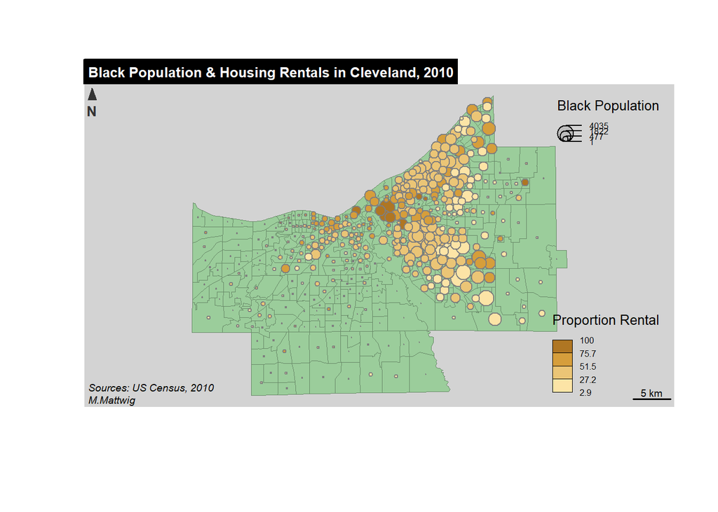

```r
## Let's first calculate the proportion of rental homes
cuyahoga$PropTenure <- cuyahoga$Rent / cuyahoga$HouseUnits * 100
## Add a base layer of the tracts
plot(st_geometry(cuyahoga), col="darkseagreen3", border="darkseagreen4",
     bg = "lightgray", lwd = 0.5)
# Plot symbols with choropleth coloration
propSymbolsChoroLayer(
  x = cuyahoga,
  var = "Black",
  inches = 0.08,
  border = "grey50",
  lwd = 1,
  legend.var.pos = "topright",
  legend.var.title.txt = "Black Population",
  legend.values.cex = 0.5,
  var2 = "PropTenure",
  method = "equal",
  nclass = 4,
  col = carto.pal(pal1 = "sand.pal", n1 = 4),
  legend.var2.values.rnd = 1,
  legend.var2.pos = "bottomright",
  legend.var2.title.txt = "Proportion Rental"
)
# layout
layoutLayer(title="Black Population & Housing Rentals in Cleveland, 2010",
            author = "M.Mattwig",
            sources = "Sources: US Census, 2010",
            scale = 5, tabtitle = TRUE, frame = FALSE)
# north arrow
north(pos = "topleft")
```

What if we wanted to read in other data that we already have? I’m reading in two vectors, landuse polygons and trail lines from Stinchfield Woods in Michigan, as shapefiles to create a map layout.

```r
landcover <- st_read("Landcover_mmattwig.shp")
trails <- st_read("Trails_mmattwig.shp")
```

Now let’s make a map layout with this data

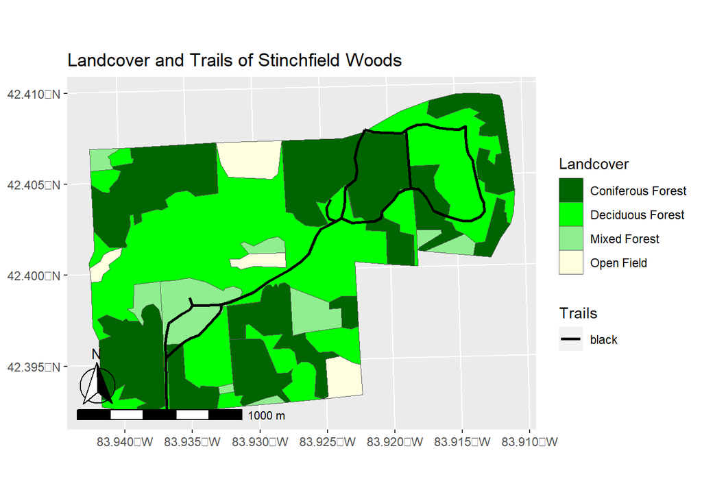

```r
col <- c("darkgreen", "green", "lightgreen", "lightyellow")

## Change attribute names so they are easier to read in legend
landcover$Landcover[landcover$Landcover == "MF"] <- "Mixed Forest"
landcover$Landcover[landcover$Landcover == "CF"] <- "Coniferous Forest"
landcover$Landcover[landcover$Landcover == "DF"] <- "Deciduous Forest"
landcover$Landcover[landcover$Landcover == "OF"] <- "Open Field"

ggplot() + geom_sf(data = landcover, lwd = 0, aes(fill = Landcover)) + scale_fill_manual(values = col) + geom_sf(data = trails, lwd = 1, aes(color = "black")) + scale_color_manual(values = "black", name = "Trails") + labs(title = "Landcover and Trails of Stinchfield Woods") + annotation_scale(location = "bl", width_hint = 0.4) + annotation_north_arrow(location = "bl", which_north = "true",
        pad_x = unit(0.0, "in"), pad_y = unit(0.2, "in"),
        style = north_arrow_fancy_orienteering)
```

So we’ve seen that we can make maps in R, but what about manipulating data? Let’s look at the [fire data from the Monitoring Trends in Burn Severity website](https://www.mtbs.gov/direct-download) that was used in Assignment 2. The Washington boundary data is retrived from the [Washington State Geospatial Open Data Portal](https://geo.wa.gov/datasets/a77ee02fab3e4793b274ec52b7a523d8/explore?location=47.149035%2C-121.191722%2C7.66)

```r
wa_boundary <- st_read("WA_State_Boundary.shp")
fires <- st_read("mtbs_FODpoints_DD.shp")
```

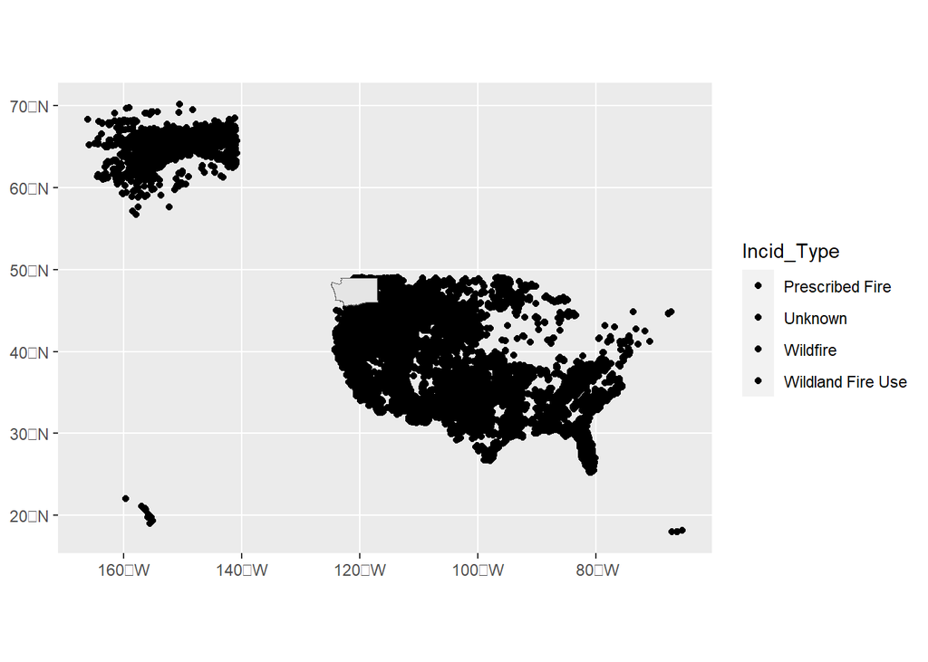

```r
ggplot() + geom_sf(data = fires, aes(fill = Incid_Type)) + geom_sf(data = wa_boundary)
```

Let’s check the projection of these layers

```r
st_crs(fires)
```

```
## Coordinate Reference System:
##   User input: NAD83
##   wkt:
## GEOGCRS["NAD83",
##     DATUM["North American Datum 1983",
##         ELLIPSOID["GRS 1980",6378137,298.257222101,
##             LENGTHUNIT["metre",1]]],
##     PRIMEM["Greenwich",0,
##         ANGLEUNIT["degree",0.0174532925199433]],
##     CS[ellipsoidal,2],
##         AXIS["latitude",north,
##             ORDER[1],
##             ANGLEUNIT["degree",0.0174532925199433]],
##         AXIS["longitude",east,
##             ORDER[2],
##             ANGLEUNIT["degree",0.0174532925199433]],
##     ID["EPSG",4269]]
```

```r
st_crs(wa_boundary)
```

```
## Coordinate Reference System:
##   User input: WGS 84 / Pseudo-Mercator
##   wkt:
## PROJCRS["WGS 84 / Pseudo-Mercator",
##     BASEGEOGCRS["WGS 84",
##         ENSEMBLE["World Geodetic System 1984 ensemble",
##             MEMBER["World Geodetic System 1984 (Transit)"],
##             MEMBER["World Geodetic System 1984 (G730)"],
##             MEMBER["World Geodetic System 1984 (G873)"],
##             MEMBER["World Geodetic System 1984 (G1150)"],
##             MEMBER["World Geodetic System 1984 (G1674)"],
##             MEMBER["World Geodetic System 1984 (G1762)"],
##             MEMBER["World Geodetic System 1984 (G2139)"],
##             ELLIPSOID["WGS 84",6378137,298.257223563,
##                 LENGTHUNIT["metre",1]],
##             ENSEMBLEACCURACY[2.0]],
##         PRIMEM["Greenwich",0,
##             ANGLEUNIT["degree",0.0174532925199433]],
##         ID["EPSG",4326]],
##     CONVERSION["Popular Visualisation Pseudo-Mercator",
##         METHOD["Popular Visualisation Pseudo Mercator",
##             ID["EPSG",1024]],
##         PARAMETER["Latitude of natural origin",0,
##             ANGLEUNIT["degree",0.0174532925199433],
##             ID["EPSG",8801]],
##         PARAMETER["Longitude of natural origin",0,
##             ANGLEUNIT["degree",0.0174532925199433],
##             ID["EPSG",8802]],
##         PARAMETER["False easting",0,
##             LENGTHUNIT["metre",1],
##             ID["EPSG",8806]],
##         PARAMETER["False northing",0,
##             LENGTHUNIT["metre",1],
##             ID["EPSG",8807]]],
##     CS[Cartesian,2],
##         AXIS["easting (X)",east,
##             ORDER[1],
##             LENGTHUNIT["metre",1]],
##         AXIS["northing (Y)",north,
##             ORDER[2],
##             LENGTHUNIT["metre",1]],
##     USAGE[
##         SCOPE["Web mapping and visualisation."],
##         AREA["World between 85.06°S and 85.06°N."],
##         BBOX[-85.06,-180,85.06,180]],
##     ID["EPSG",3857]]
```

Let’s re-project both of these data layers to be in UTM Zone 10 North so it’s a better projection for Washington state

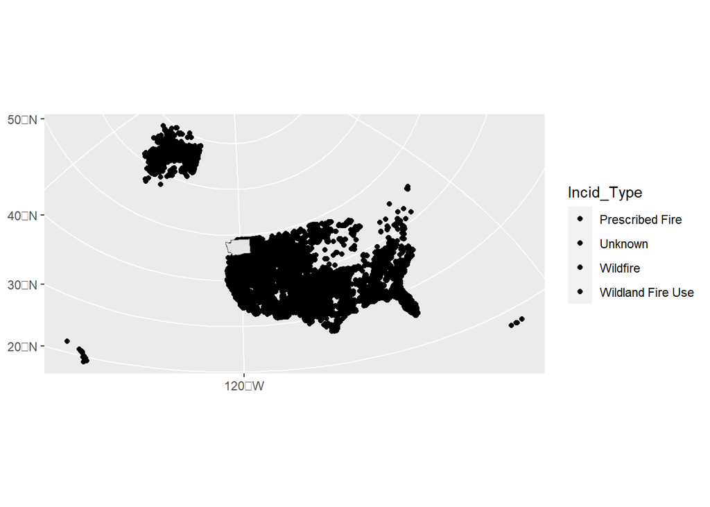

```r
wa_boundary <- st_transform(wa_boundary, crs = 32610)
fires <- st_transform(fires, crs = 32610)

ggplot() + geom_sf(data = fires, aes(fill = Incid_Type)) + geom_sf(data = wa_boundary)
```

Now let’s clip the fire data to the Washington state boundary

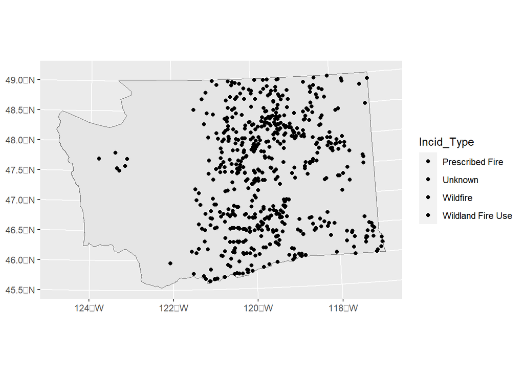

```r
## Here we are actually subsetting, but for all intents and purposes it is the same as clipping in ArcGIS Pro
wa_fires <- fires[wa_boundary, ]

## Map of clipped data
ggplot() + geom_sf(data = wa_boundary) +geom_sf(data = wa_fires, aes(fill = Incid_Type))
```

What if we want to compare fire occurrences over multiple years?

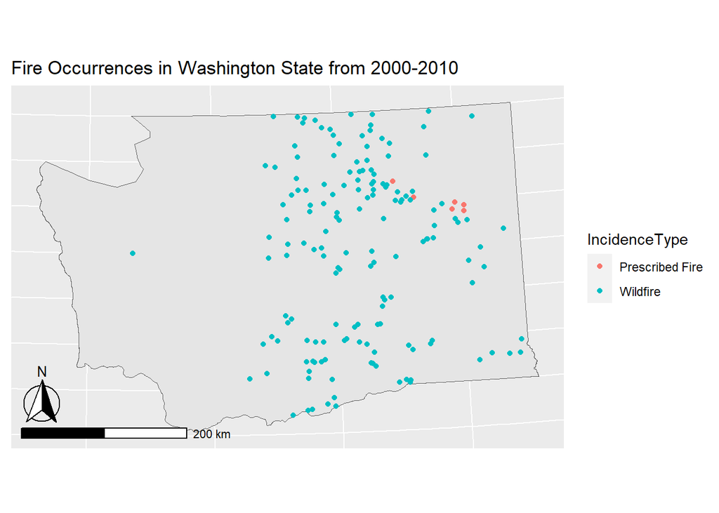

```r
## First, we need to convert the Ig_Date column to be of type 'date'
wa_fires$Ig_Date <- as.Date(wa_fires$Ig_Date)

## Now we will subset the dates we want
wa_fires2000_2010 <- wa_fires[wa_fires$Ig_Date > "2000-01-01" & wa_fires$Ig_Date < "2010-01-01",]
wa_fires2010_2020 <- wa_fires[wa_fires$Ig_Date > "2010-01-01" & wa_fires$Ig_Date < "2020-01-01",]

## Now we'll remove any unknown fires from our analysis
wa_fires2000_2010 <- wa_fires2000_2010[wa_fires2000_2010$Incid_Type == "Prescribed Fire" |
                                         wa_fires2000_2010$Incid_Type == "Wildfire",]
wa_fires2010_2020 <- wa_fires2010_2020[wa_fires2010_2020$Incid_Type == "Prescribed Fire" |
                                         wa_fires2010_2020$Incid_Type == "Wildfire",]

colnames(wa_fires2000_2010)[4] <- 'IncidenceType'
colnames(wa_fires2010_2020)[4] <- 'IncidenceType'

wa_2000_2010_map <- ggplot() + geom_sf(data = wa_boundary) + geom_sf(data = wa_fires2000_2010, aes(color = IncidenceType)) +
  theme(axis.text.y=element_blank(), axis.ticks.y=element_blank(), axis.text.x=element_blank(), axis.ticks.x=element_blank()) + labs(title = "Fire Occurrences in Washington State from 2000-2010") + annotation_scale(location = "bl", width_hint = 0.4) + annotation_north_arrow(location = "bl", which_north = "true",
        pad_x = unit(0.0, "in"), pad_y = unit(0.2, "in"),
        style = north_arrow_fancy_orienteering)

wa_2010_2020_map <- ggplot() + geom_sf(data = wa_boundary) +geom_sf(data = wa_fires2010_2020, aes(color = IncidenceType)) +
  theme(axis.text.y=element_blank(), axis.ticks.y=element_blank(), axis.text.x=element_blank(), axis.ticks.x=element_blank())+ labs(title = "2010-2020") + annotation_scale(location = "bl", width_hint = 0.4) + annotation_north_arrow(location = "bl", which_north = "true",
        pad_x = unit(0.0, "in"), pad_y = unit(0.2, "in"),
        style = north_arrow_fancy_orienteering)

wa_2000_2010_map
```

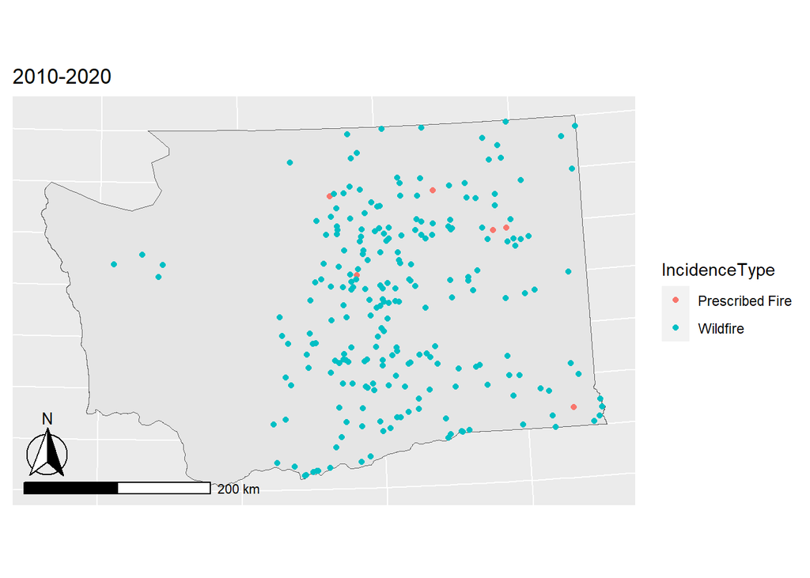

```r
wa_2010_2020_map
```

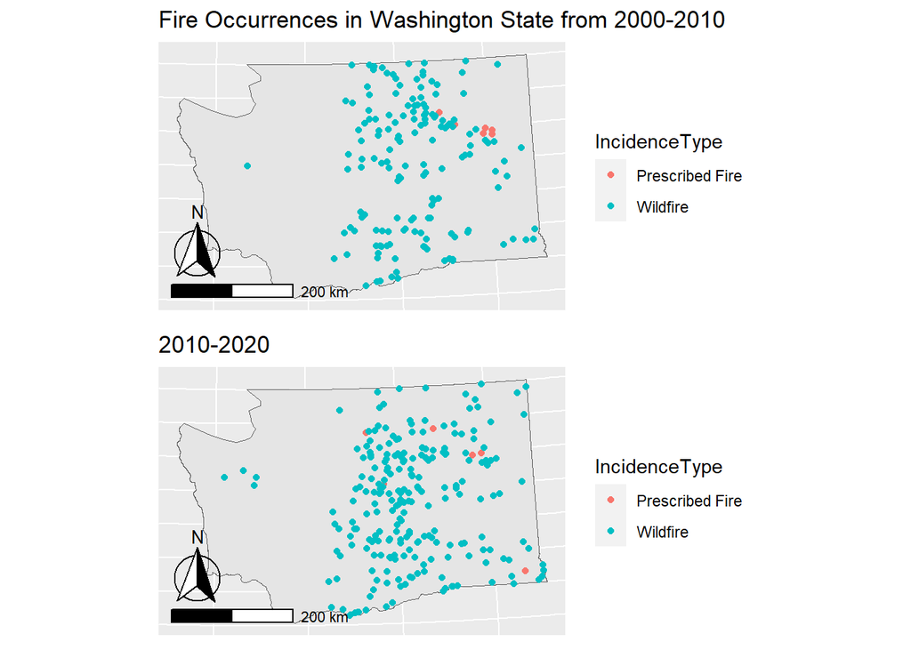

```r
maps <- ggarrange(wa_2000_2010_map, wa_2010_2020_map, ncol = 1, nrow = 2)
maps
```